[figure not shown]

# DATA TRANSFORMATION • PART 2

## ISIS SANTOS COSTA • 2020

## Tʀᴀɴsғᴏʀᴍᴀᴛɪᴏɴ • Resuming: retrieving the DFs

```python
import pandas as pd
```

```python
df_orders_orig = pd.read_csv('orders.csv') # original data
df_trips_orig = pd.read_csv('trips.csv') # original data
```

```python
df_orders = pd.read_csv('df_orders.csv') # transformed data
df_trips = pd.read_csv('df_trips.csv') # transformed data
```

```python
df_orders.drop(df_orders.columns[0], axis = 1, inplace = True)
df_orders.head(2)
```

|  | order_id | passenger_id | pickup_datetime | pickup_longitude | pickup_latitude | payment_type |
| --- | --- | --- | --- | --- | --- | --- |
| 0 | 6433697 | 5234567816269547 | 2014-04-11 18:06:45 | -74.015684 | 40.714476 | CRD |
| 1 | 6433698 | 5234567812367422 | 2014-04-12 00:20:28 | -73.958403 | 40.713247 | CRD |

```python
df_trips.drop(df_trips.columns[0], axis = 1, inplace = True)
df_trips.head(2)
```

|  | order_id | pickup_datetime | dropoff_datetime | trip_distance | pickup_longitude | pickup_latitude | rate_code | dropoff_longitude | dropoff_latitude | payment_type | fare_amount | tip_amount | total_amount | passenger_id |
| --- | --- | --- | --- | --- | --- | --- | --- | --- | --- | --- | --- | --- | --- | --- |
| 0 | 718300 | 2014-05-24 09:08:43 | 2014-05-24 09:19:06 | 2.1 | -73.967172 | 40.769851 | 1 | -73.995022 | 40.765441 | CRD | 9.5 | 2.5 | 12.5 | 5234567815585627 |
| 1 | 14054197 | 2014-04-10 15:14:12 | 2014-04-10 15:49:05 | 12.4 | -73.991044 | 40.749704 | 1 | -73.909173 | 40.823500 | CSH | 39.0 | 0.0 | 39.5 | 5234567812372271 |

## Tʀᴀɴsғᴏʀᴍᴀᴛɪᴏɴ • Checking & improving the data structure (cont'd.)

### Rate type (cont'd.)

*Rate type has been previously cleaned given to records extraneous to the data range.* 🧹  
🔄 *A further useful step is to convert the codes into readable information, as follows:*

```python
replace_dict = {'1': 'Standard'}
replace_dict['2'] = 'JFK'
replace_dict['3'] = 'Newark'
replace_dict['4'] = 'Nassau / Westchester'
replace_dict['5'] = 'Negotiated'
replace_dict['6'] = 'Group ride'
replace_dict
```

```
{'1': 'Standard',
 '2': 'JFK',
 '3': 'Newark',
 '4': 'Nassau / Westchester',
 '5': 'Negotiated',
 '6': 'Group ride'}
```

```python
df_trips['rate_code'] = df_trips['rate_code'].astype(str)
df_trips['rate_code'] = df_trips['rate_code'].replace(replace_dict)
df_trips = df_trips.rename(columns = {'rate_code': 'rate_type'})
df_trips.head()
```

|  | order_id | pickup_datetime | dropoff_datetime | trip_distance | pickup_longitude | pickup_latitude | rate_type | dropoff_longitude | dropoff_latitude | payment_type | fare_amount | tip_amount | total_amount | passenger_id |
| --- | --- | --- | --- | --- | --- | --- | --- | --- | --- | --- | --- | --- | --- | --- |
| 0 | 718300 | 2014-05-24 09:08:43 | 2014-05-24 09:19:06 | 2.10 | -73.967172 | 40.769851 | Standard | -73.995022 | 40.765441 | CRD | 9.5 | 2.5 | 12.5 | 5234567815585627 |
| 1 | 14054197 | 2014-04-10 15:14:12 | 2014-04-10 15:49:05 | 12.40 | -73.991044 | 40.749704 | Standard | -73.909173 | 40.823500 | CSH | 39.0 | 0.0 | 39.5 | 5234567812372271 |
| 2 | 2961792 | 2014-03-21 19:05:00 | 2014-03-21 19:33:00 | 12.37 | -73.971610 | 40.743485 | JFK | -73.810440 | 40.691472 | CRD | 52.0 | 10.4 | 62.9 | 5234567813993786 |
| 3 | 4561755 | 2014-04-02 20:14:00 | 2014-04-02 20:23:00 | 1.63 | -73.987733 | 40.743752 | Standard | -74.006530 | 40.731562 | CRD | 8.5 | 1.0 | 10.5 | 5234567812381379 |
| 4 | 3298376 | 2014-03-25 22:24:00 | 2014-03-25 22:28:00 | 0.83 | -73.979562 | 40.737337 | Standard | -73.988807 | 40.731392 | CSH | 5.0 | 0.0 | 6.0 | 5234567819313166 |

## Tʀᴀɴsғᴏʀᴍᴀᴛɪᴏɴ • Basic information

```python
df_orders.info()
```

```
<class 'pandas.core.frame.DataFrame'>
RangeIndex: 15000000 entries, 0 to 14999999
Data columns (total 6 columns):
 #   Column            Dtype
---  ------            -----
 0   order_id          int64
 1   passenger_id      int64
 2   pickup_datetime   object
 3   pickup_longitude  float64
 4   pickup_latitude   float64
 5   payment_type      object
dtypes: float64(2), int64(2), object(2)
memory usage: 686.6+ MB
```

```python
df_trips.info()
```

```
<class 'pandas.core.frame.DataFrame'>
RangeIndex: 11456227 entries, 0 to 11456226
Data columns (total 14 columns):
 #   Column             Dtype
---  ------             -----
 0   order_id           int64
 1   pickup_datetime    object
 2   dropoff_datetime   object
 3   trip_distance      float64
 4   pickup_longitude   float64
 5   pickup_latitude    float64
 6   rate_type          object
 7   dropoff_longitude  float64
 8   dropoff_latitude   float64
 9   payment_type       object
 10  fare_amount        float64
 11  tip_amount         float64
 12  total_amount       float64
 13  passenger_id       int64
dtypes: float64(8), int64(2), object(4)
memory usage: 1.2+ GB
```

```python
df_orders.describe()
```

|  | order_id | passenger_id | pickup_longitude | pickup_latitude |
| --- | --- | --- | --- | --- |
| count | 1.500000e+07 | 1.500000e+07 | 1.500000e+07 | 1.500000e+07 |
| mean | 7.500000e+06 | 5.234568e+15 | -7.262919e+01 | 4.000893e+01 |
| std | 4.330127e+06 | 3.870524e+06 | 9.889962e+00 | 5.448031e+00 |
| min | 1.000000e+00 | 5.234568e+15 | -1.714464e+02 | 0.000000e+00 |
| 25% | 3.750001e+06 | 5.234568e+15 | -7.399212e+01 | 4.073476e+01 |
| 50% | 7.500000e+06 | 5.234568e+15 | -7.398188e+01 | 4.075263e+01 |
| 75% | 1.125000e+07 | 5.234568e+15 | -7.396731e+01 | 4.076701e+01 |
| max | 1.500000e+07 | 5.234568e+15 | 1.213851e+00 | 6.312818e+01 |

```python
df_trips.describe()
```

|  | order_id | trip_distance | pickup_longitude | pickup_latitude | dropoff_longitude | dropoff_latitude | fare_amount | tip_amount | total_amount | passenger_id |
| --- | --- | --- | --- | --- | --- | --- | --- | --- | --- | --- |
| count | 1.145623e+07 | 1.145623e+07 | 1.145623e+07 | 1.145623e+07 | 1.145623e+07 | 1.145623e+07 | 1.145623e+07 | 1.145623e+07 | 1.145623e+07 | 1.145623e+07 |
| mean | 7.500133e+06 | 2.909636e+00 | -7.262986e+01 | 4.000929e+01 | -7.256022e+01 | 3.997215e+01 | 1.242631e+01 | 1.481080e+00 | 1.499246e+01 | 5.234568e+15 |
| std | 4.329823e+06 | 1.438006e+01 | 9.887587e+00 | 5.446732e+00 | 1.012975e+01 | 5.581360e+00 | 1.021169e+01 | 2.276245e+00 | 1.237402e+01 | 3.867525e+06 |
| min | 2.000000e+00 | 0.000000e+00 | -1.714464e+02 | 0.000000e+00 | -1.714464e+02 | 0.000000e+00 | 0.000000e+00 | 0.000000e+00 | 0.000000e+00 | 5.234568e+15 |
| 25% | 3.750708e+06 | 1.020000e+00 | -7.399212e+01 | 4.073477e+01 | -7.399138e+01 | 4.073346e+01 | 6.500000e+00 | 0.000000e+00 | 8.000000e+00 | 5.234568e+15 |
| 50% | 7.500416e+06 | 1.770000e+00 | -7.398188e+01 | 4.075263e+01 | -7.397991e+01 | 4.075306e+01 | 9.500000e+00 | 1.000000e+00 | 1.130000e+01 | 5.234568e+15 |
| 75% | 1.125000e+07 | 3.200000e+00 | -7.396731e+01 | 4.076701e+01 | -7.396281e+01 | 4.076830e+01 | 1.400000e+01 | 2.000000e+00 | 1.680000e+01 | 5.234568e+15 |
| max | 1.500000e+07 | 3.318000e+04 | 1.213851e+00 | 6.312818e+01 | 1.218270e+02 | 4.009167e+02 | 5.000000e+02 | 2.000000e+02 | 6.266700e+02 | 5.234568e+15 |

🕒 *From 'info' we see that pickup/dropoff datetime have been recorded as 'object', let's convert to a handable format.*

## Tʀᴀɴsғᴏʀᴍᴀᴛɪᴏɴ • Converting strings into datetime

```python
df_orders['pickup_datetime'].dtype
```

```
dtype('O')
```

```python
df_orders['pickup_datetime'] = pd.to_datetime(df_orders['pickup_datetime'])
df_orders['pickup_datetime'].dtype
```

```
dtype('<M8[ns]')
```

```python
df_trips['pickup_datetime'].dtype
```

```
dtype('O')
```

```python
df_trips['pickup_datetime'] = pd.to_datetime(df_trips['pickup_datetime'])
df_trips['pickup_datetime'].dtype
```

```
dtype('<M8[ns]')
```

```python
df_trips['dropoff_datetime'].dtype
```

```
dtype('O')
```

```python
df_trips['dropoff_datetime'] = pd.to_datetime(df_trips['dropoff_datetime'])
df_trips['dropoff_datetime'].dtype
```

```
dtype('<M8[ns]')
```

📏 *Now we can have a description for the pickup / dropoff datetimes as well*

```python
df_orders['pickup_datetime'].describe()
```

```
count                15000000
unique                2608032
top       2014-03-13 20:10:00
freq                      214
first     2014-03-01 00:00:00
last      2014-05-31 18:45:00
Name: pickup_datetime, dtype: object
```

```python
df_orders['pickup_datetime'].describe(datetime_is_numeric=True)
```

```
count                         15000000
mean     2014-04-06 02:47:43.160677632
min                2014-03-01 00:00:00
25%         2014-03-15 20:39:51.500000
50%                2014-04-06 11:28:00
75%      2014-04-22 06:21:17.249999872
max                2014-05-31 18:45:00
Name: pickup_datetime, dtype: object
```

```python
df_trips['pickup_datetime'].describe(datetime_is_numeric=True)
```

```
count                         11456227
mean     2014-04-06 02:56:01.900459520
min                2014-03-01 00:00:00
25%                2014-03-15 20:45:00
50%                2014-04-06 11:32:49
75%                2014-04-22 06:40:00
max                2014-05-31 18:45:00
Name: pickup_datetime, dtype: object
```

```python
df_trips['dropoff_datetime'].describe(datetime_is_numeric=True)
```

```
count                         11456227
mean     2014-04-06 03:08:54.517428992
min                2014-03-01 00:01:00
25%                2014-03-15 20:56:56
50%                2014-04-06 11:43:03
75%                2014-04-22 06:49:00
max                2014-05-31 18:57:00
Name: dropoff_datetime, dtype: object
```

📅 *Now we know we have data from March to May 2014.* 🧐

## Tʀᴀɴsғᴏʀᴍᴀᴛɪᴏɴ • Feature engineering: datetime 📅

*Knowing our date span, it is now possible to think of what transformations/binnings could render meaningful insights:*

- Date [without time, may be useful for some visualizations]: gives information on the trend within the period
- Day of the week: to get information on the seasonality along the week
- Week: as the time span of data is short, weeks seem a useful aggregation
- Working day / Weekend: to get information on these chunks for seasonality
- Period of the day: it would be interesting to have information by period (like 'early morning', 'noon', etc.), but... as NY is always busy, rush/no rush may be more informative. Let's have also the time by just the hour.
- Hour of the day
- Rush / no rush: reported as morning: 7:00 a.m. to 10:00 a.m., afternoon: 3:00 p.m. to 8:00 p.m.
- Duration of the trip

### Orders

```python
df_orders['pickup_date'] = pd.to_datetime(pd.DatetimeIndex(df_orders['pickup_datetime']).date)
df_orders['pickup_date'].head(2)
```

```
0   2014-04-11
1   2014-04-12
Name: pickup_date, dtype: datetime64[ns]
```

```python
dayofweek_dict= {'0': 'Monday'}
dayofweek_dict['1'] = 'Tuesday'
dayofweek_dict['2'] = 'Wednesday'
dayofweek_dict['3'] = 'Thursday'
dayofweek_dict['4'] = 'Friday'
dayofweek_dict['5'] = 'Saturday'
dayofweek_dict['6'] = 'Sunday'
dayofweek_dict
```

```
{'0': 'Monday',
 '1': 'Tuesday',
 '2': 'Wednesday',
 '3': 'Thursday',
 '4': 'Friday',
 '5': 'Saturday',
 '6': 'Sunday'}
```

```python
df_orders['pickup_dayofweek'] = pd.to_datetime(pd.DatetimeIndex(df_orders['pickup_datetime']).dayofweek).astype(str)
df_orders['pickup_dayofweek'] = [x.strip()[-1] for x in df_orders['pickup_dayofweek']]
df_orders['pickup_dayofweek'] = df_orders['pickup_dayofweek'].replace(dayofweek_dict)
df_orders['pickup_dayofweek'].head(2)
```

```
0      Friday
1    Saturday
Name: pickup_dayofweek, dtype: object
```

```python
df_orders['pickup_dayofweek'] = pd.to_datetime(pd.DatetimeIndex(df_orders['pickup_datetime']).dayofweek).astype(str)
df_orders['pickup_dayofweek'] = df_orders['pickup_dayofweek'].str[-1:]
df_orders['pickup_dayofweek'] = df_orders['pickup_dayofweek'].replace(dayofweek_dict)
df_orders['pickup_dayofweek'].head(2)
```

```
0      Friday
1    Saturday
Name: pickup_dayofweek, dtype: object
```

```python
100 * df_orders['pickup_dayofweek'].value_counts() / len(df_orders)
```

```
Saturday     15.996093
Wednesday    14.747733
Tuesday      14.210333
Friday       14.005933
Sunday       13.931160
Thursday     13.635200
Monday       13.473547
Name: pickup_dayofweek, dtype: float64
```

```python
df_orders['pickup_week'] = df_orders['pickup_datetime'].dt.isocalendar().week
100 * df_orders['pickup_week'].value_counts() / len(df_orders)
```

```
10    11.917600
11    11.675867
14    11.470160
17    11.435653
15    11.432467
16    11.108400
13     6.279707
12     6.210000
20     5.427427
21     4.921507
18     4.723733
9      3.390320
19     0.006707
22     0.000453
Name: pickup_week, dtype: float64
```

```python
df_orders['pickup_isweekend'] = df_orders['pickup_dayofweek'].apply(lambda x: 1 if (x == 'Saturday' or x == 'Sunday') else 0)
100 * df_orders['pickup_isweekend'].value_counts() / len(df_orders)
```

```
0    70.072747
1    29.927253
Name: pickup_isweekend, dtype: float64
```

```python
df_orders['pickup_hour'] = pd.DatetimeIndex(df_orders['pickup_datetime']).hour
100 * df_orders['pickup_hour'].value_counts() / len(df_orders)
```

```
19    6.290800
20    6.049227
18    6.030213
21    5.883387
22    5.673133
14    4.970333
23    4.934867
17    4.913173
12    4.877427
13    4.817840
15    4.728493
11    4.706893
9     4.702560
10    4.552213
8     4.549787
16    3.970867
0     3.901160
7     3.724280
1     2.819600
6     2.166507
2     2.029747
3     1.540280
4     1.152107
5     1.015107
Name: pickup_hour, dtype: float64
```

```python
df_orders['pickup_isrush'] = df_orders['pickup_hour'].apply(lambda x: 1 if ((x >= 7 and x <= 10) or (x >= 15 and x <= 20)) else 0)
100 * df_orders['pickup_isrush'].value_counts() / len(df_orders)
```

```
0    50.488387
1    49.511613
Name: pickup_isrush, dtype: float64
```

### Trips

```python
df_trips['pickup_date'] = pd.to_datetime(pd.DatetimeIndex(df_trips['pickup_datetime']).date)
df_trips['pickup_date'].head(2)
```

```
0   2014-05-24
1   2014-04-10
Name: pickup_date, dtype: datetime64[ns]
```

```python
df_trips['pickup_dayofweek'] = pd.to_datetime(pd.DatetimeIndex(df_trips['pickup_datetime']).dayofweek).astype(str)
df_trips['pickup_dayofweek'] = df_trips['pickup_dayofweek'].str[-1:]
df_trips['pickup_dayofweek'] = df_trips['pickup_dayofweek'].replace(dayofweek_dict)
df_trips['pickup_dayofweek'].head(2)
```

```
0    Saturday
1    Thursday
Name: pickup_dayofweek, dtype: object
```

```python
100 * df_trips['pickup_dayofweek'].value_counts() / len(df_trips)
```

```
Saturday     16.004527
Wednesday    14.739303
Tuesday      14.208413
Friday       14.006339
Sunday       13.931716
Thursday     13.633782
Monday       13.475920
Name: pickup_dayofweek, dtype: float64
```

```python
df_trips['pickup_week'] = df_trips['pickup_datetime'].dt.isocalendar().week
100 * df_trips['pickup_week'].value_counts() / len(df_trips)
```

```
10    11.915241
11    11.669942
14    11.472878
17    11.437413
15    11.430657
16    11.104363
13     6.279781
12     6.212386
20     5.425573
21     4.925758
18     4.731069
9      3.387695
19     0.006809
22     0.000436
Name: pickup_week, dtype: float64
```

```python
df_trips['pickup_isweekend'] = df_trips['pickup_dayofweek'].apply(lambda x: 1 if (x == 'Saturday' or x == 'Sunday') else 0)
100 * df_trips['pickup_isweekend'].value_counts() / len(df_trips)
```

```
0    70.063757
1    29.936243
Name: pickup_isweekend, dtype: float64
```

```python
df_trips['pickup_hour'] = pd.DatetimeIndex(df_trips['pickup_datetime']).hour
100 * df_trips['pickup_hour'].value_counts() / len(df_trips)
```

```
19    6.290666
20    6.044678
18    6.037119
21    5.882862
22    5.669249
14    4.971637
23    4.935168
17    4.914855
12    4.875637
13    4.817982
15    4.732500
11    4.703521
9     4.699985
8     4.553541
10    4.550661
16    3.969719
0     3.903982
7     3.723390
1     2.819183
6     2.167913
2     2.026339
3     1.540551
4     1.153739
5     1.015125
Name: pickup_hour, dtype: float64
```

```python
df_trips['pickup_isrush'] = df_trips['pickup_hour'].apply(lambda x: 1 if ((x >= 7 and x <= 10) or (x >= 15 and x <= 20)) else 0)
100 * df_trips['pickup_isrush'].value_counts() / len(df_trips)
```

```
0    50.482886
1    49.517114
Name: pickup_isrush, dtype: float64
```

```python
df_trips['duration'] = df_trips['dropoff_datetime'] - df_trips['pickup_datetime']
df_trips['duration'].head(2)
```

```
0   0 days 00:10:23
1   0 days 00:34:53
Name: duration, dtype: timedelta64[ns]
```

```python
df_trips['duration'].describe()
```

```
count                     11456227
mean     0 days 00:12:52.617283159
std      0 days 00:23:29.733588487
min             -25 days +23:53:21
25%                0 days 00:06:10
50%                0 days 00:10:22
75%                0 days 00:16:46
max                3 days 23:57:04
Name: duration, dtype: object
```

```python
df_trips['duration_minutes'] = df_trips['duration'].dt.seconds / 60
df_trips['duration_minutes'].head(2)
```

```
0    10.383333
1    34.883333
Name: duration_minutes, dtype: float64
```

```python
df_trips['duration_minutes'].describe()
```

```
count    1.145623e+07
mean     1.295463e+01
std      1.339357e+01
min      0.000000e+00
25%      6.166667e+00
50%      1.036667e+01
75%      1.678333e+01
max      1.439833e+03
Name: duration_minutes, dtype: float64
```

```python
durationtype_dict= {max(df_trips['duration_minutes']): '>60min'}
durationtype_dict[60] = '40-60min'
durationtype_dict[40] = '30-40min'
durationtype_dict[30] = '20-30min'
durationtype_dict[20] = '10-20min'
durationtype_dict[10] = '5-10min'
durationtype_dict[ 5] = '<=5min'
durationtype_dict
```

```
{1439.8333333333333: '>60min',
 60: '40-60min',
 40: '30-40min',
 30: '20-30min',
 20: '10-20min',
 10: '5-10min',
 5: '<=5min'}
```

```python
df_durationtype = pd.DataFrame.from_dict(durationtype_dict, orient='index')
df_durationtype
```

|  | 0 |
| --- | --- |
| 1439.833333 | >60min |
| 60.000000 | 40-60min |
| 40.000000 | 30-40min |
| 30.000000 | 20-30min |
| 20.000000 | 10-20min |
| 10.000000 | 5-10min |
| 5.000000 | <=5min |

```python
# df_durationtype.reset_index(inplace = True)
df_durationtype
```

[output not shown]

```python
df_durationtype.rename(columns = {'index': 'duration_minutes', 0: 'duration_type'}, inplace = True)
df_durationtype
```

[output not shown]

```python
df_trips['duration_type'] = df_trips['duration_minutes']

for i in range(len(df_durationtype)):
    df_trips.loc[df_trips['duration_minutes'] <= df_durationtype['duration_minutes'][i], 'duration_type'] = df_durationtype['duration_type'][i]
```

```python
df_trips['duration_type'].head()
```

```
0    10-20min
1    30-40min
2    20-30min
3     5-10min
4      <=5min
Name: duration_type, dtype: object
```

```python
df_trips['duration_minutes'].head()
```

```
0    10.383333
1    34.883333
2    28.000000
3     9.000000
4     4.000000
Name: duration_minutes, dtype: float64
```

```python
100 * df_trips['duration_type'].value_counts() / len(df_trips)
```

```
10-20min    34.494428
5-10min     30.983159
<=5min      18.059445
20-30min    11.040712
30-40min     3.369382
40-60min     1.675569
>60min       0.377306
Name: duration_type, dtype: float64
```

```python
df_trips_duration = 100 * df_trips['duration_type'].value_counts() / len(df_trips)
df_trips_duration
```

```
10-20min    34.494428
5-10min     30.983159
<=5min      18.059445
20-30min    11.040712
30-40min     3.369382
40-60min     1.675569
>60min       0.377306
Name: duration_type, dtype: float64
```

```python
%matplotlib inline

import matplotlib as mpl
import matplotlib.pyplot as plt

mpl.style.use('ggplot')
```

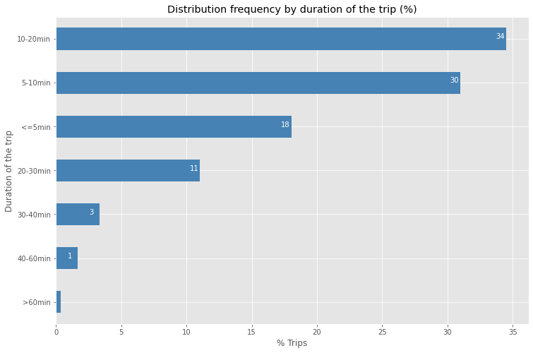

```python
## Distribution %

df_trips_duration.sort_values(ascending=True, inplace=True)
df_trips_duration.plot(kind='barh', figsize=(12, 8), color='steelblue')
plt.xlabel('% Trips')
plt.ylabel('Duration of the trip')
plt.title('Distribution frequency by duration of the trip (%)')

for i, value in enumerate(df_trips_duration):
    label = format(int(value), ',') # format int with commas

    # place text at the end of bar (subtracting 47000 from x, and 0.1 from y to make it fit within the bar)
    plt.annotate(label, xy=(value - 0.8, i - 0), color='white')

plt.show()
```

## Tʀᴀɴsғᴏʀᴍᴀᴛɪᴏɴ • Treating missing data

```python
df_orders.isnull().sum()
```

```
order_id            0
passenger_id        0
pickup_datetime     0
pickup_longitude    0
pickup_latitude     0
payment_type        0
pickup_date         0
pickup_dayofweek    0
pickup_week         0
pickup_isweekend    0
pickup_hour         0
pickup_isrush       0
dtype: int64
```

```python
df_trips.isnull().sum()
```

```
order_id             0
pickup_datetime      0
dropoff_datetime     0
trip_distance        0
pickup_longitude     0
pickup_latitude      0
rate_type            0
dropoff_longitude    0
dropoff_latitude     0
payment_type         0
fare_amount          0
tip_amount           0
total_amount         0
passenger_id         0
pickup_date          0
pickup_dayofweek     0
pickup_week          0
pickup_isweekend     0
pickup_hour          0
pickup_isrush        0
duration             0
duration_minutes     0
duration_type        0
dtype: int64
```

🥳 *No missing data, yay!!!* 🎉

## Exporting results for retrieval

```python
#df_orders.to_csv('df_orders.csv')
```

```python
#df_trips_trsf.to_csv('df_trips.csv')
```

*Note: This Notebook would entail the whole transforming process, but as some instabilities may interrupt the Kernel requiring a restart from zero, it has been split for a smoothier process.*

# Next: Transformation, part 3 (Final!) (lat, long) ➔ neighborhoods